# Adding a new variable to the Dictionary

# Setting up the dictionary - example of a small environmental model

After the conceptual work and selection of variables to be used in the model, a dictionary must be created for all variables that are not yet contained in the original dictionary that comes with the aggregate model package. Make sure to double check whether variables selected for the model to be created might not already exist in the initial dictionary.

Detailed instructions on how to add variables to the existing dictionary can be found in the [vignette “Adding a new variable to the Dictionary”](https://moritzschwarz.org/aggregate.model/articles/new_variable_to_dict.html).

The example below shows the setting up of the directory for a small rudimentary model on emissions in Austria

```r
dict %>%
  #This is an example of a variable added from Edgar:
  bind_rows(tibble(
    model_varname = "N2O_soils", #choose a name for the variable that is unique
    full_name = "Direct N2O Emissions from managed soils", #Enter the full name/describe the variable
    database  = "edgar", #specify the data source
    dataset_id = "https://jeodpp.jrc.ec.europa.eu/ftp/jrc-opendata/EDGAR/datasets/v80_FT2022_GHG/EDGAR_N2O_m_1970_2022b.zip", #include the link to the data set
    freq = "m", #indicate the time frequency (can be m for monthly or q for quarterly)
    ipcc_sector = "3.C.4", #for Edgar variables, specify the ipcc_sector information (to be found in the excel data file the variable is contained in)
    geo = "AT" )) %>% #set the geographical region for the model, add a pipe operator to add multiple variables to the dictionary at once
  #This is an example of a variable added from Eurostat:
  bind_rows(tibble(
    model_varname = "Price_agrpro",
    full_name = "Price indices of agricultural products, output",
    database  = "eurostat", #define database as eurostat
    variable_code = "140000", #add the variable code (this specifies which details the variable should represent)
    dataset_id = "apri_pi20_outq", #add the dataset ID
    var_col = "product", #add the column name the variable code specification was chosen from
    freq = "q",
    geo = "AT",
    unit = "I20", #if given, define the unit
    s_adj = "NSA", #chose between seasonally adjusted or unadjusted data (if given)
    nace_r2 = "B-D")) %>% #define the nace_r2 sector specification, if applicable
  bind_rows(tibble(
    model_varname = "Price_animpro",
    full_name = "Price indices of agricultural products - Agricultural goods output",
    database  = "eurostat",
    variable_code = "140000",
    dataset_id = "apri_pi15_outq",
    var_col = "product",
    freq = "q",
    geo = "AT",
    unit = "I15",
    p_adj = "NI")) %>%
  bind_rows(tibble(
    model_varname = "ind_N2O_mm",
    full_name = "Indirect N2O Emissions from manure management",
    database  = "edgar",
    ipcc_sector = "3.C.6",
    dataset_id = "https://jeodpp.jrc.ec.europa.eu/ftp/jrc-opendata/EDGAR/datasets/v80_FT2022_GHG/EDGAR_N2O_m_1970_2022b.zip",
    freq = "m",
    geo = "AT")) %>%
  bind_rows(tibble(
    model_varname = "Flights",
    full_name = "National air passenger transport by reporting country",
    database  = "eurostat",
    variable_code = "CAF_PAS",
    dataset_id = "avia_panc",
    var_col = "tra_meas",
    freq = "m",
    geo = "AT",
    unit = "FLIGHT")) %>%
  bind_rows(tibble(
    model_varname = "Prod_Constr_Manu",
    full_name = "Production in Construction",
    database  = "eurostat",
    variable_code = "PROD",
    dataset_id = "sts_copr_m",
    var_col = "indic_bt",
    freq = "m",
    geo = "AT",
    unit = "I21",
    s_adj = "NSA",
    nace_r2 = "B-D_F")) %>%
  bind_rows(tibble(
    model_varname = "CO2_aviation",
    full_name = "CO2 (fossil) emissions from Civil Aviation",
    database  = "edgar",
    ipcc_sector = "1.A.3.a",
    dataset_id = "https://jeodpp.jrc.ec.europa.eu/ftp/jrc-opendata/EDGAR/datasets/v80_FT2022_GHG/IEA_EDGAR_CO2_m_1970_2022b.zip",
    freq = "m",
    geo = "AT")) %>%
  bind_rows(tibble(
    model_varname = "CO2_roads",
    full_name = "CO2 (bio) emissions from Road",
    database  = "edgar",
    ipcc_sector = "1.A.3.b_noRES",
    dataset_id = "https://jeodpp.jrc.ec.europa.eu/ftp/jrc-opendata/EDGAR/datasets/v80_FT2022_GHG/IEA_EDGAR_CO2_m_1970_2022b.zip",
    freq = "m",
    geo = "AT")) %>%
  bind_rows(tibble(
    model_varname = "CO2_Manufactoring",
    full_name = "CO2 (fossil) emissions from Manufacturing Industries and Construction",
    database  = "edgar",
    ipcc_sector = "1.A.2",
    dataset_id = "https://jeodpp.jrc.ec.europa.eu/ftp/jrc-opendata/EDGAR/datasets/v80_FT2022_GHG/IEA_EDGAR_CO2_m_1970_2022b.zip",
    freq = "m",
    geo = "AT")) %>%
  bind_rows(tibble(
    model_varname = "CO2_Residential",
    full_name = "CO2 (fossil) emissions from Residential and other sectors",
    database  = "edgar",
    ipcc_sector = "1.A.4",
    dataset_id = "https://jeodpp.jrc.ec.europa.eu/ftp/jrc-opendata/EDGAR/datasets/v80_FT2022_GHG/IEA_EDGAR_CO2_m_1970_2022b.zip",
    freq = "m",
    geo = "AT")) %>%
  bind_rows(tibble(
    model_varname = "Prod_Constr_Build",
    full_name = "Production in Construction",
    database  = "eurostat",
    variable_code = "PROD",
    dataset_id = "sts_copr_m",
    var_col = "indic_bt",
    freq = "m",
    geo = "AT",
    unit = "I21",
    s_adj = "NSA",
    nace_r2 = "F41")) %>%
  bind_rows(tibble(
    model_varname = "Lab_In_Constr",
    full_name = "Labour input in construction",
    database  = "eurostat",
    variable_code = "EMPL",
    dataset_id = "sts_colb_m",
    var_col = "indic_bt",
    freq = "m",
    geo = "AT",
    unit = "I21",
    s_adj = "NSA",
    nace_r2 = "F")) %>%
  bind_rows(tibble(
    model_varname = "Lab_In_Indus",
    full_name = "Labour input in industry",
    database  = "eurostat",
    variable_code = "EMPL",
    dataset_id = "sts_inlb_m",
    var_col = "indic_bt",
    freq = "m",
    geo = "AT",
    unit = "I21",
    s_adj = "NSA",
    nace_r2 = "B-E36")) %>%
  bind_rows(tibble(
    model_varname = "Elect_cons",
    full_name = "Consumption of electricity - GWh",
    database  = "eurostat",
    variable_code = "IS-CEL-GWH",
    dataset_id = "ei_isen_m",
    var_col = "indic",
    freq = "m",
    geo = "AT",
    unit = "NA",
    s_adj = "NSA",
    nace_r2 = "B-D")) %>%
  bind_rows(tibble(
    model_varname = "Animal_imp",
    full_name = "Total imports of live animals",
    database  = "eurostat",
    variable_code = "SL",
    dataset_id = "apro_mt_pheadm",
    var_col = "meatitem",
    freq = "m",
    geo = "AT",
    unit = "THS_T",
    s_adj = "NSA",
    nace_r2 = "B-D",
    meat = "B1000")) %>%
  bind_rows(tibble(
    model_varname = "GDP_new",
    full_name = "GDP and main aggregates - international data cooperation quarterly data",
    database  = "eurostat",
    variable_code = "B1GQ",
    dataset_id = "naidq_10_gdp",
    var_col = "na_item",
    freq = "q",
    geo = "AT",
    unit = "CP_MNAC",
    s_adj = "NSA",
    nace_r2 = "B-D")) -> environment_dict #give your new dictionary an original name
```

# Specifying the model

After the dictionary is completed, the following code should be used to specify the model by specifying which variables to use as dependent and which ones as independent variables. Again, drawing on the conceptual pre-analysis, it might be useful to draw on (scientific) reports and articles to identify which variables would best serve as independent variables for the dependent variables chosen. Based on that, the model specification will specify equations of independent variables that together will factor into the equivalent dependent variables.

In the example below, emissions from agriculture (through managed soils), transport (flight behaviour), manufactoring (industry), and housing/buildings were chosen as the four dependent variables that rudimentally make up general emissions in Austria. For each dependent variable, a set of independent variables has been selected:

```r
specification <- dplyr::tibble(
  type = c(
    "n",
    "n",
    "n",
    "n"
  ),
  dependent = c(
    "N2O_soils",
    "CO2_aviation",
    "CO2_Manufactoring",
    "CO2_Residential"
  ),
  independent = c(
    "ind_N2O_mm + Price_animpro + Animal_imp",
    "GDP_new + Flights",
    "Prod_Constr_Manu + Prod_Constr_Build + Lab_In_Constr +  Lab_In_Indus",
    "Elect_cons + HDD + BuildingPermits"
  )
)
specification
```

```
#> # A tibble: 4 × 3
#>   type  dependent         independent
#>   <chr> <chr>             <chr>
#> 1 n     N2O_soils         ind_N2O_mm + Price_animpro + Animal_imp
#> 2 n     CO2_aviation      GDP_new + Flights
#> 3 n     CO2_Manufactoring Prod_Constr_Manu + Prod_Constr_Build + Lab_In_Constr …
#> 4 n     CO2_Residential   Elect_cons + HDD + BuildingPermits
```

# Running the model

As soon as all relevant variables were added and the model has been specified, the “run model” function can be applied. This function can be further used for model diagnostics and forecasting.

Example using the small environmental model:

```r
model <- run_model(specification = specification,
                   dictionary = environment_dict,
                   inputdata_directory = "small_examples/environmental_model/", #make sure to edit this accordingly to where your model specification is stored
                   primary_source = "local",

                   # modify save_to_disk for each new country/specification
                   # this avoids having to download the same data multiple times
                   save_to_disk = "small_examples/environmental_model/Environmental_model_V2.R",

                   quiet = FALSE,
                   saturation.tpval = 0.001,
                   constrain.to.minimum.sample = FALSE)
```

[output not shown]

```r
# you can use these few lines to print a table of the model results to get some inital insides
library(modelsummary)
```

# Model diagnostics

```r
model_list <- lapply(model$module_collection$model, gets::as.lm)
names(model_list) <- model$module_order$dependent

modelsummary::modelsummary(
  model_list,
  coef_omit = "iis|sis",
  gof_omit = "R",
  title = "Final models run for each sub-module for the illustrative example of Austria.",
  notes = "Impulse (IIS) and Step Indicators (SIS) are not shown individually but were activated for all models.",
  stars = TRUE
)
```

Final models run for each sub-module for the illustrative example of Austria.

|  | N2O_soils | CO2_aviation | CO2_Manufactoring | CO2_Residential |
| --- | --- | --- | --- | --- |
| mconst | 2.098*** | 0.035* | 0.105 | 6.278*** |
|  | (0.070) | (0.015) | (0.094) | (0.162) |
| ln.ind_N2O_mm | 0.636*** |  |  |  |
|  | (0.024) |  |  |  |
| ar1 |  | 0.990*** | 0.997*** |  |
|  |  | (0.005) | (0.012) |  |
| q_2 |  |  | −0.208*** |  |
|  |  |  | (0.005) |  |
| q_3 |  |  | −0.261*** |  |
|  |  |  | (0.005) |  |
| q_4 |  |  | 0.152*** |  |
|  |  |  | (0.005) |  |
| trend |  |  |  | −0.003*** |
|  |  |  |  | (0.001) |
| ln.HDD |  |  |  | 0.323*** |
|  |  |  |  | (0.022) |
| Num.Obs. | 212 | 211 | 211 | 176 |
| AIC | −1150.9 | −812.3 | −979.9 | 5.9 |
| BIC | −1110.6 | −782.2 | −946.3 | 21.7 |
| Log.Lik. | 587.454 | 415.174 | 499.927 | 2.074 |

+ p < 0.1, * p < 0.05, ** p < 0.01, *** p < 0.001  
Impulse (IIS) and Step Indicators (SIS) are not shown individually but were activated for all models.

```r
diagnostics_model(model) %>%
  rename(Module = module,
         `Indicator Share` = indicator_share) %>%
  kable(booktabs = TRUE, digits = 3, label = "diagnostics", caption = "Diagnostic results for each sub-module.") %>%
  kable_styling()
```

Diagnostic results for each sub-module.

| Module | AR | ARCH | IIS | SIS | n | Indicator Share |
| --- | --- | --- | --- | --- | --- | --- |
| N2O_soils | 0.000 | 0.000 | 0 | 9 | 212 | 0.042 |
| CO2_aviation | 0.527 | 0.250 | 6 | 0 | 211 | 0.028 |
| CO2_Manufactoring | 0.950 | 0.136 | 4 | 0 | 211 | 0.019 |
| CO2_Residential | 0.964 | 0.730 | 0 | 1 | 176 | 0.006 |

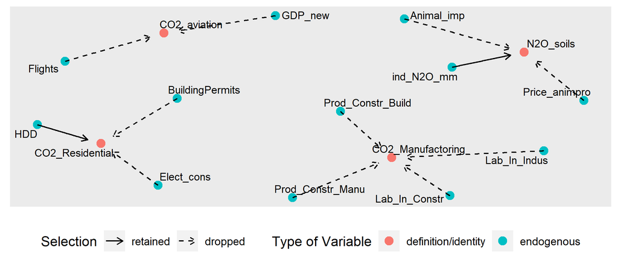

```r
# show the network graph
model %>%
  network()
```

# Forecasting

```r
# -- Forecasting ----------
f1 <- forecast_model(model, exog_fill_method = "AR")
```

```
#> No exogenous values provided. Model will forecast the exogenous values with an AR4 process (incl. Q dummies, IIS and SIS w 't.pval = 0.001').
#> Alternative is exog_fill_method = 'last'.
```

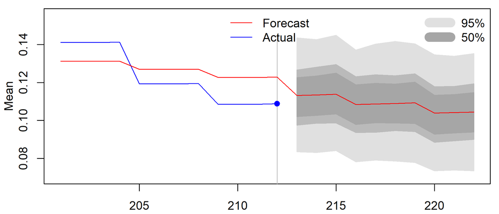

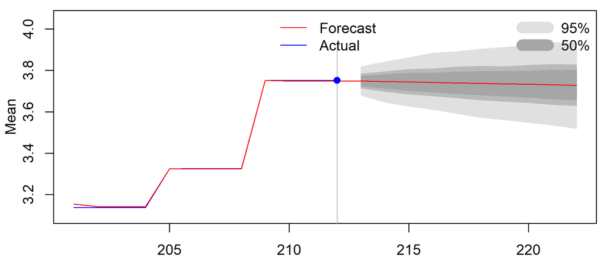

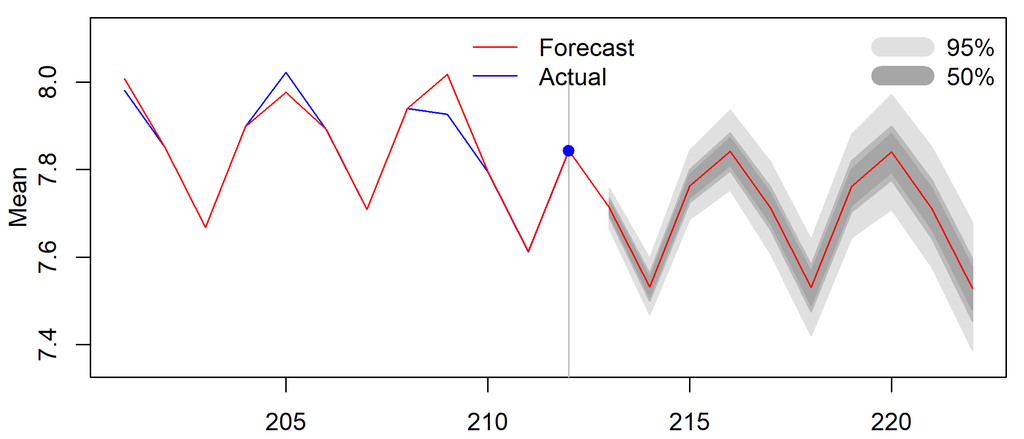

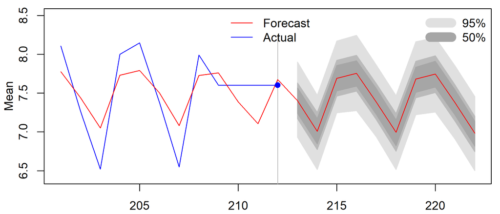

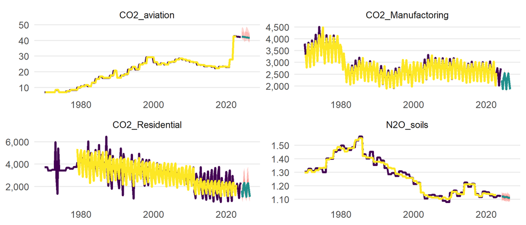

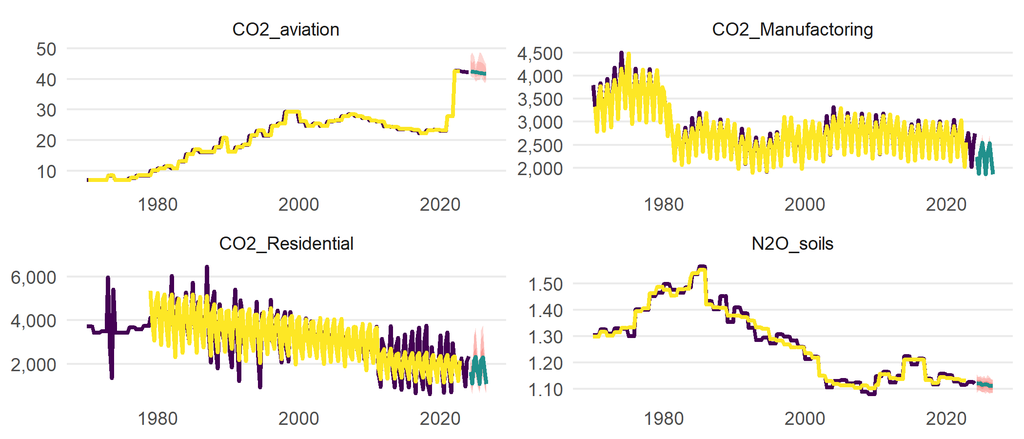

```r
f2 <- forecast_model(model, exog_fill_method = "auto", plot.forecast = FALSE)
```

```
#> No exogenous values provided. Model will forecast the exogenous values with the auto.arima().
```

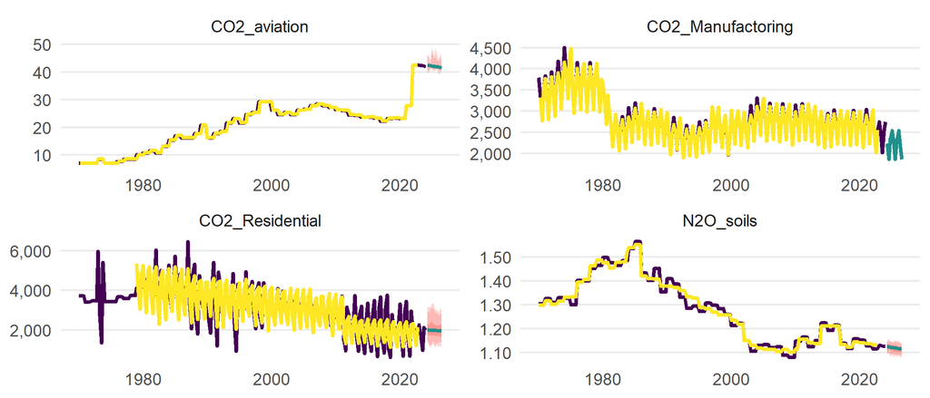

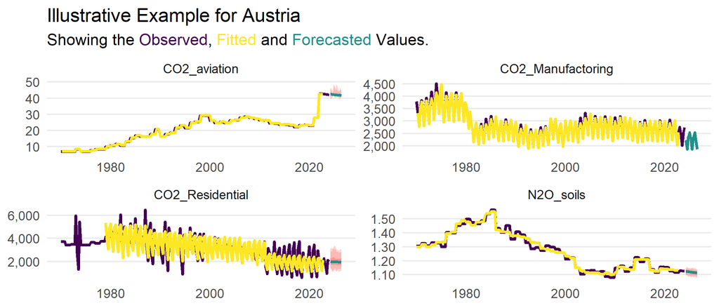

```r
# -- Forecasting Plotting ---------------

plot(f2) +
  labs(title = "Illustrative Example for Austria", subtitle = "Showing the <span style = color:#440154FF>Observed</span>, <span style = color:#FDE725FF>Fitted</span> and <span style = color:#21908CFF>Forecasted</span> Values.") +
  theme(text = element_text(family = "Myriad Pro"),
        plot.subtitle = element_markdown()) #-> p
```

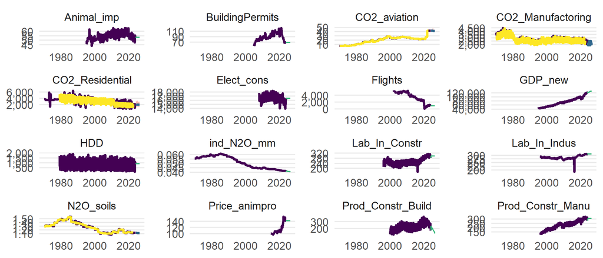

[output not shown]

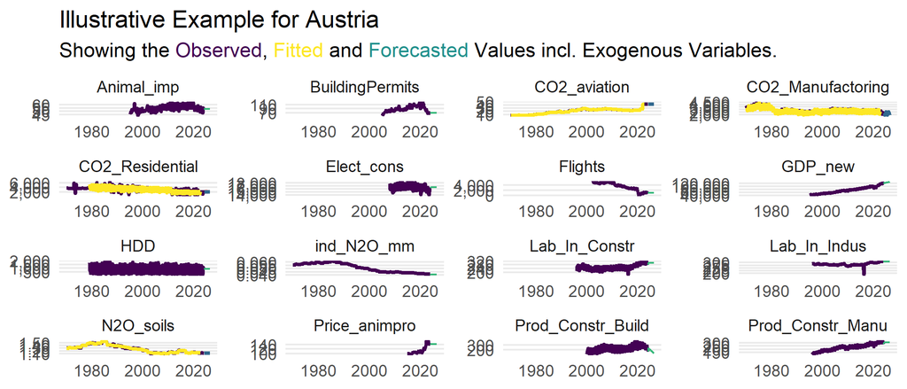

```r
# ggsave(p, width = 7, height = 5, file = "data-raw/test_for_now/EAERE_forecast_simple.pdf", device = cairo_pdf)


plot(f2, exclude.exogenous = FALSE) +
  labs(title = "Illustrative Example for Austria", subtitle = "Showing the <span style = color:#440154FF>Observed</span>, <span style = color:#FDE725FF>Fitted</span> and <span style = color:#21908CFF>Forecasted</span> Values incl. Exogenous Variables.") +
  theme(text = element_text(family = "Myriad Pro"),
        plot.subtitle = element_markdown()) #-> p
```

```r
# ggsave(p, width = 7, height = 5, file = "data-raw/test_for_now/EAERE_forecast_inclexog.pdf", device = cairo_pdf)
```

# Insample Forecasting

```r
# Insample Forecasting ----------------------------------------------------
# Here we use hindcasts to check the validity of our model
# this takes quite a bit of time, so make sure to do this wisely (check everything before)
# then perhaps try to only use .95 for the first run
# then extend to e.g. .9 or .8 to check if the model really works

f2_insample <- forecast_insample(model, sample_share = .97, exog_fill_method = "auto")

# you can also change the exog_fill_method to e.g. "AR" or "last"

f2_insample$plot


extract_dep_vars <- f2_insample$central %>% distinct(dep_var) %>% pull

ggplot2::ggplot() +
  ggplot2::geom_line(data = model$full_data %>%
                       rename(dep_var = na_item) %>%
                       filter(dep_var %in% extract_dep_vars,
                              time > as.Date("2010-01-01")),
                     ggplot2::aes(x = .data$time, y = .data$values), linewidth = 1) +

  ggplot2::facet_wrap(~dep_var, scales = "free") +
  ggplot2::geom_ribbon(data = f2_insample$uncertainty, ggplot2::aes(ymin = .data$min, x = .data$time, ymax = .data$max, fill = as.factor(.data$start)), linewidth = 0.1, alpha = 0.1, inherit.aes = FALSE) +
  ggplot2::geom_ribbon(data = f2_insample$uncertainty, ggplot2::aes(ymin = .data$p025, x = .data$time, ymax = .data$p975, fill = as.factor(.data$start)), linewidth = 0.1, alpha = 0.1, inherit.aes = FALSE) +
  ggplot2::geom_ribbon(data = f2_insample$uncertainty, ggplot2::aes(ymin = .data$p25, x = .data$time, ymax = .data$p75, fill = as.factor(.data$start)), linewidth = 0.1, alpha = 0.1, inherit.aes = FALSE) +

  ggplot2::geom_line(data = f2_insample$central, ggplot2::aes(y = .data$value, x = .data$time, color = as.factor(.data$start)), inherit.aes = FALSE) +
  ggplot2::facet_wrap(~.data$dep_var, scales = "free") +
  #ggplot2::scale_color_brewer(palette = "PRGn") +
  ggplot2::scale_colour_viridis_d() +
  ggplot2::coord_cartesian(expand = TRUE) +

  ggplot2::labs(x = NULL, y = NULL, title = "Automatic Forecasting Hindcasts") +
  ggplot2::theme_minimal() +
  ggplot2::theme(legend.position = "none",
                 text = element_text(family = "Myriad Pro"),
                 panel.grid.major.x = ggplot2::element_blank(),
                 panel.grid.minor.x = ggplot2::element_blank(),
                 panel.grid.minor.y = ggplot2::element_blank())
```

[output not shown]